# The Impact of Oil Price on Airline Stock Performance

**Student:** Rauf Nasirli

**Live Website:** https://raufnasirli.github.io

## **Project Idea and Motivation**

Airlines operate in an industry where fuel costs heavily influence financial performance. Fuel is one of their largest and most unpredictable expenses, so movements in crude oil prices immediately affect profitability. When crude oil prices increase, operating costs rise and airline margins shrink. When prices decrease, airlines benefit from lower expenses and stronger earnings. Since jet fuel is refined directly from crude oil, changes in major benchmarks such as West Texas Intermediate and Brent often pass quickly into jet fuel prices. These shifts can then influence how airline stocks behave in the short term.

This project examines how fluctuations in crude oil and jet fuel prices relate to stock movements in major United States airlines including Delta, American, United, and Southwest. These companies are widely traded and highly sensitive to changes in fuel conditions, which makes them ideal for studying the connection between energy markets and financial markets. For investors and analysts, knowing how strongly airline stocks react to oil price changes provides useful insight for forecasting and risk assessment. For airline managers, it highlights the importance of strategies such as hedging, long term fuel planning, and investments in efficient aircraft. More broadly, the project shows how global events that influence crude oil prices can affect industries outside the energy sector, illustrating how data driven analysis can help explain these relationships. In summary:

### Problem - Why oil price volatility matters for airlines?

- Fuel is one of the largest and most unpredictable operating expenses for airline companies.
- Changes in crude oil or jet fuel prices directly influence planning, budgeting, and daily operating decisions.
- Incorrect fuel cost projections can weaken airline stock performance and reduce investor confidence.

### Motivation - What benefits does this analysis provide?

- Understanding these relationships will helps airlines and investors stay profitable.
- It supports better planning and strategic decision-making for airline companies.
- It also helps companies to have better risk management strategies.

## Key Domain Terms

**Fuel Exposure**  
The degree to which changes in fuel prices influence an airline’s operating costs, profitability, and stock performance.

**WTI Crude Oil Price**  
West Texas Intermediate is a major benchmark for crude oil. It reflects conditions in the United States energy market and is widely used as a reference price for global oil trading.

**Jet Fuel Price**  
The refined petroleum product used by airlines. Jet fuel prices represent a direct measure of fuel cost for airline operators and often react more sharply to market disruptions than crude oil.

**Airline Stock Returns**  
The daily percentage change in the stock price of an airline. In this project we use log returns, which measure the natural logarithm of the price ratio from one day to the next. Log returns make different assets comparable and simplify statistical analysis.

**Airline Tickers**  
DAL represents Delta Air Lines.  
AAL represents American Airlines.  
UAL represents United Airlines.  
LUV represents Southwest Airlines.  
These tickers are used to identify each airline in the market data.

**Daily Log Return**  
A transformation of daily price changes that takes the natural logarithm of the ratio of consecutive prices. This measure removes long term trends, stabilizes the scale, and helps compare assets with different price levels.

**Normalized Price Series**  
A transformation that sets the first value of a price series to one and scales all other values relative to that starting point. Normalization is used to compare growth patterns of different assets on the same chart.

**Volatility**  
A measure of how much returns fluctuate over time. In this project we compute rolling volatility using the standard deviation of daily log returns. Higher volatility means greater uncertainty and larger price movements.

**Correlation**  
A statistic that measures how closely two financial series move together. Positive values indicate the series move in the same direction. Negative values indicate they move in opposite directions. Values near zero indicate little connection.

**Rolling Correlation**  
A dynamic correlation computed over a moving time window. It shows how relationships between variables such as jet fuel and airline stocks change over time.

**Regression Model**  
A statistical tool that estimates how much changes in WTI and jet fuel explain changes in airline stock returns. In this project we use simple ordinary least squares models to compare sensitivity across airlines.

## **Datasets**

- **Crude Oil Benchmarks (FRED – Federal Reserve Economic Data)**
  - WTI Spot Price: DCOILWTICO
  - Brent Spot Price: DCOILBRENTEU  
    These series provide daily spot prices for the two most watched oil benchmarks. The data is free, public, and updated frequently.
- **Airline Stock Prices (Yahoo Finance)**
  - Delta Airlines (DAL): DAL
  - American Airlines (AAL): AAL
  - United Airlines (UAL): UAL
  - Southwest Airlines (LUV): LUV  
    Yahoo Finance provides daily adjusted close prices, which are corrected for dividends and stock splits.

## **Research Questions**

1. **How do changes in crude oil prices influence jet fuel prices, and how do these fuel cost dynamics affect airline stock performance?**

   This question focuses on the relationship between global energy markets and airline financial outcomes. Because jet fuel is refined from crude oil, movements in oil prices often translate into changes in jet fuel costs, which are a major component of airline operating expenses. By examining how fluctuations in oil prices feed into jet fuel prices and, in turn, into airline stock performance, this analysis highlights how energy cost volatility shapes profitability, investor expectations, and short-term market behavior in the airline industry.
2. **Which airlines appear more resilient to rising fuel costs, and what factors might explain these differences?**

   This question investigates which airlines are better positioned to manage increases in fuel costs and the factors that contribute to that resilience. The analysis highlights how operational efficiency, fuel hedging, and business strategy shape each airline’s ability to navigate periods of energy price volatility.
3. **Between crude oil and jet fuel prices, which serves as a stronger indicator of airline performance, and how can this insight support financial forecasting or risk management?**

   This question evaluates whether crude oil or jet fuel prices provide a stronger explanation for changes in airline performance. The results can help both managers and investors focus on the most relevant energy indicators when developing forecasts or planning risk mitigation strategies.

## ETL and Analysis Plan

For this notebook, we created a complete ETL pipeline to prepare the data for time series analysis and modeling. Our goal was to build a clean and consistent dataset that supports correlation analysis, rolling volatility measures, beta estimation, lagged relationships, and event based evaluation.

1. Extract WTI crude oil prices and Jet Fuel spot prices from FRED using pandas datareader.
2. Extract daily stock prices for Delta, American, United, and Southwest from Yahoo Finance using yfinance.
3. Align all series on a unified daily date index and handle missing dates through forward filling so that every variable has a complete time series.
4. Merge the WTI, Jet Fuel, and airline stock data into a single tidy DataFrame for analysis.
5. Compute daily log returns for all variables in order to place them on a comparable scale and remove long term trends.
6. Prepare the cleaned returns dataset for statistical work, including correlation analysis, rolling volatility calculations, lagged return relationships, and regression modeling.
7. Estimate rolling beta values to measure how sensitive each airline stock is to movements in crude oil returns over different window lengths.
8. Conduct event based analysis to examine how airline stocks react to major economic and geopolitical periods such as market shocks, political events, and energy price disruptions.

This ETL process created a reliable and structured dataset that supports every analytical step in the project. It confirms that we can extract real world financial and energy data, clean it into a unified format, apply transformations such as log returns, and prepare the data for meaningful statistical and visual analysis in Python.

## **Collaboration Plan**

Although I am completing this project as a graduate student working individually, I will follow best practices in project management. All code will be maintained in a private GitHub repository and published as a webpage on `raufnasirli.github.io`.

## **Assumptions and Data Challenges**

During the ETL and cleaning stages, we began to notice several practical challenges in the raw data. These issues also appeared during the early steps of visualization and modeling. These challenges emerged as we aligned different data sources, examined missing values, observed price behavior over time, and tested how well the variables performed in statistical models. The points below summarize the specific issues we encountered and explain the reasoning behind how we addressed them.

• **Non stationarity:** Both crude oil prices and stock prices show long term drift rather than stable averages. This became clear through plots and summary statistics. For meaningful modeling, we use daily returns instead of raw prices.

• **Data accuracy and consistency:** All data was obtained from reputable sources such as FRED, EIA, and Yahoo Finance. While these sources are considered reliable, missing values and slight timing differences required careful cleaning to maintain consistency.

• **Simplified study scope:** This study examines short term market relationships between crude oil, jet fuel, and airline stock prices. Broader economic factors such as demand shifts, currency movements, or policy changes are beyond the scope of this analysis.

# Section 1. Setup and Data Download

In this section, we prepare the environment and obtain the raw data needed for the analysis. We install the required Python packages, import the necessary libraries, define the time period for the study, and download all datasets used in the project. The dataset includes WTI crude oil spot prices and jet fuel spot prices from FRED, as well as Adjusted Close prices for major U.S. airlines (DAL, AAL, UAL, LUV) from Yahoo Finance.

```python
# Section 1.1 — Install required packages

!pip install yfinance pandas_datareader --quiet
```

## 1.2 Import libraries

Next, we import the libraries that we will use for:

- handling data (`pandas`, `numpy`)
- working with dates (`datetime`)
- pulling financial data (`yfinance`)
- pulling macro/commodity data from FRED (`pandas_datareader`)

```python
# Section 1.2 — Import libraries

import pandas as pd
import numpy as np
import yfinance as yf
from pandas_datareader import data as pdr
from datetime import datetime, timedelta
```

## 1.3 Define the time period

We define our sample period as the last 5 years from the day the notebook is run. This ensures that the analysis is always based on recent data.

In code, we:

- set `end_date` to today's date
- set `start_date` to approximately 5 years earlier
- print both dates so the exact period is documented

```python
# Section 1.3 — Define time period (last 5 years)

end_date = datetime.today()
start_date = end_date - timedelta(days=5*365)  # approximate 5 years

print("Start date:", start_date.date())
print("End date:", end_date.date())
```

```
Start date: 2020-12-11
End date: 2025-12-10
```

### 1.4 Download WTI crude oil prices (FRED: DCOILWTICO)

We download daily WTI crude oil spot prices from the Federal Reserve Economic Data (FRED) database. WTI stands for West Texas Intermediate, which is a major U.S. benchmark for crude oil prices.

**Series ID:** DCOILWTICO — the official FRED code for the daily WTI spot price  
**Units:** U.S. dollars per barrel  
**Frequency:** daily, with some missing days due to weekends and holidays

We store this series in a DataFrame named `wti`, rename the column to `WTI`, and use it throughout the analysis for consistency.

```python
# Section 1.4 — Download WTI crude oil prices

wti = pdr.DataReader(
    name="DCOILWTICO",
    data_source="fred",
    start=start_date,
    end=end_date
)

wti.rename(columns={"DCOILWTICO": "WTI"}, inplace=True)

print("WTI crude oil data (head):")
print(wti.head())
print("\nWTI data shape:", wti.shape)
```

```
WTI crude oil data (head):
              WTI
DATE
2020-12-14  47.02
2020-12-15  47.58
2020-12-16  47.86
2020-12-17  48.34
2020-12-18  49.04

WTI data shape: (1301, 1)
```

## 1.5 Download Jet Fuel prices (FRED: DJFUELUSGULF)

Next, we download daily **U.S. Gulf Coast Kerosene-Type Jet Fuel spot prices** from FRED.

- Series ID: `DJFUELUSGULF`
- Units: U.S. dollars per gallon
- Frequency: daily (with gaps on some days)

We store the series in a DataFrame called `jet` and rename the column to `JetFuel`.

```python
# Section 1.5 — Download Jet fuel prices

jet = pdr.DataReader(
    name="DJFUELUSGULF",
    data_source="fred",
    start=start_date,
    end=end_date
)

jet.rename(columns={"DJFUELUSGULF": "JetFuel"}, inplace=True)

print("Jet fuel data (head):")
print(jet.head())
print("\nJet fuel data shape:", jet.shape)
```

```
Jet fuel data (head):
            JetFuel
DATE
2020-12-14    1.338
2020-12-15    1.346
2020-12-16    1.350
2020-12-17    1.373
2020-12-18    1.388

Jet fuel data shape: (1301, 1)
```

### 1.6 Download airline stock prices (Yahoo Finance)

Finally, we download daily **Adjusted Close** prices for four major U.S. airlines from Yahoo Finance:

- **DAL** — Delta Air Lines
- **AAL** — American Airlines Group
- **UAL** — United Airlines Holdings
- **LUV** — Southwest Airlines

**What does “Adjusted Close” mean?**  
Adjusted Close is the stock price that has been corrected for dividends, stock splits, and other corporate actions. These adjustments ensure that historical prices remain consistent over time, especially when calculating returns.

**Why we use Adjusted Close:**  
Because it reflects the *true economic value* of holding the stock on each day, Adjusted Close is the standard and correct choice for computing returns in financial analysis.

```python
# Section 1.6 — Download airline stock prices

tickers = ["DAL", "AAL", "UAL", "LUV"]

# auto_adjust=True is now default, so Close is already adjusted
stocks = yf.download(
    tickers,
    start=start_date,
    end=end_date,
    progress=False
)["Close"]

print("Airline stocks (Close) data head:")
print(stocks.head())
print("\nStocks data shape:", stocks.shape)
```

```
Airline stocks (Close) data head:
Ticker            AAL        DAL        LUV        UAL
Date
2020-12-14  16.700001  39.584839  42.293167  46.720001
2020-12-15  17.010000  40.713333  43.377129  47.459999
2020-12-16  16.860001  39.964249  42.732361  46.000000
2020-12-17  16.799999  39.993427  43.349094  45.880001
2020-12-18  16.510000  39.575108  43.012691  44.740002

Stocks data shape: (1254, 4)
```

### Conclusion for Section 1

In this section, we downloaded all raw data required for the analysis, including daily WTI crude oil prices, daily jet fuel prices, and daily closing prices for major U.S. airlines. We defined the study period as the most recent five years to capture current market dynamics. Daily frequency is used because it is the highest consistent resolution available across all data sources. FRED provides oil and jet fuel prices only at daily intervals, and airline stocks naturally trade on a daily cycle. Hourly data are not available for oil and jet fuel, and using monthly data would smooth out short-term reactions that are crucial for understanding how fuel price changes transmit into airline stock movements. Therefore, daily data represent the correct, consistent, and most informative choice for this study.

## Section 2. Aligning and Merging Price Data

In this section, we put all series on a single consistent daily timeline and combine them into one DataFrame. First, we create a master daily date index that runs from the earliest date in any series to the latest date. Then we reindex the WTI, jet fuel, and airline stock data to this index and forward-fill missing values, so each day has a defined price equal to the most recent available observation. Finally, we merge the three datasets into a single DataFrame called `prices`, where each row corresponds to a date and each column corresponds to a price series. This aligned price dataset will be the basis for computing returns and running the exploratory analysis.

```python
# Section 2 — Aligning and Merging Price Data

# ---- Creating a unified daily date index across all datasets ----
# Finding the earliest and latest dates across WTI, Jet Fuel, and airline stock data
# to define a single continuous timeline shared by all series.
min_date = min(wti.index.min(), jet.index.min(), stocks.index.min())
max_date = max(wti.index.max(), jet.index.max(), stocks.index.max())

# Building a complete daily date range that spans the entire period.
full_index = pd.date_range(start=min_date, end=max_date, freq="D")
print("Unified index from", full_index.min().date(), "to", full_index.max().date())
print("Number of days in unified index:", len(full_index))

# ---- Reindexing each dataset onto the unified timeline ----
# Reindexing and forward-filling missing dates (weekends/holidays) so that
# every series has a value for every day in the timeline.
wti_full = wti.reindex(full_index).ffill()
jet_full = jet.reindex(full_index).ffill()
stocks_full = stocks.reindex(full_index).ffill()

print("\nShapes after reindexing and forward-fill:")
print("WTI:", wti_full.shape)
print("JetFuel:", jet_full.shape)
print("Stocks:", stocks_full.shape)

# ---- Merging all aligned series into a single DataFrame ----
# Combining WTI, Jet Fuel, and airline stock prices column-wise to create
# one unified price table.
prices = pd.concat([wti_full, jet_full, stocks_full], axis=1)

# Renaming the index and arranging columns in a consistent order for readability.
prices.index.name = "Date"
prices = prices[["WTI", "JetFuel"] + tickers]

print("\nMerged prices shape:", prices.shape)
print("\nMissing values per column:")
print(prices.isna().sum())

print("\nHead of merged prices:")
print(prices.head())
```

```
Unified index from 2020-12-14 to 2025-12-10
Number of days in unified index: 1823

Shapes after reindexing and forward-fill:
WTI: (1823, 1)
JetFuel: (1823, 1)
Stocks: (1823, 4)

Merged prices shape: (1823, 6)

Missing values per column:
WTI        0
JetFuel    0
DAL        0
AAL        0
UAL        0
LUV        0
dtype: int64

Head of merged prices:
              WTI  JetFuel        DAL        AAL        UAL        LUV
Date
2020-12-14  47.02    1.338  39.584839  16.700001  46.720001  42.293167
2020-12-15  47.58    1.346  40.713333  17.010000  47.459999  43.377129
2020-12-16  47.86    1.350  39.964249  16.860001  46.000000  42.732361
2020-12-17  48.34    1.373  39.993427  16.799999  45.880001  43.349094
2020-12-18  49.04    1.388  39.575108  16.510000  44.740002  43.012691
```

## Section 3. Computing Daily Log Returns

In this section, we convert all price series into **daily log returns**. Price levels cannot be compared directly across oil, jet fuel, and airline stocks because each series operates on a different scale and follows long-term trends. Log returns solve this by measuring the **relative day-to-day percentage change** in each series.

To compute log returns, we take the natural logarithm of each price series and calculate the first difference. The daily log return formula is:

$$ r_{t} = \ln(P_{t}) - \ln(P_{t-1}) = \ln\left(\frac{P_{t}}{P_{t-1}}\right) $$

This transformation standardizes all variables, removes long-term trends, and produces a clean **returns** DataFrame used for all subsequent analysis and visualization.

For more info, check: https://quant.stackexchange.com/questions/70997/how-to-calculate-the-log-return-of-portfolio

```python
# Section 3 — Computing Daily Log Returns

# Take natural log of prices
log_prices = np.log(prices)

# Compute daily log returns
returns = log_prices.diff().dropna()

# Print basic info
print("Returns shape:", returns.shape)
print("\nHead of returns:")
print(returns.head())
```

```
Returns shape: (1822, 6)

Head of returns:
                 WTI   JetFuel       DAL       AAL       UAL       LUV
Date
2020-12-15  0.011839  0.005961  0.028109  0.018393  0.015715  0.025307
2020-12-16  0.005868  0.002967 -0.018570 -0.008857 -0.031246 -0.014976
2020-12-17  0.009979  0.016894  0.000730 -0.003565 -0.002612  0.014329
2020-12-18  0.014377  0.010866 -0.010515 -0.017413 -0.025161 -0.007791
2020-12-19  0.000000  0.000000  0.000000  0.000000  0.000000  0.000000
```

### Section 4.1. Normalized Price Trend: WTI vs Jet Fuel

In this step, we compare how crude oil prices and jet fuel prices moved over time by normalizing both series to a common starting point. Normalization sets the first value of each series to 1 and scales the remaining values accordingly. This allows us to compare their relative growth or decline on the same chart, even though the two series have very different price levels.

The normalization formula is:

$$ \text{Normalized Value}_t = \frac{P_t}{P_0} $$

where:

- (P_t) is the price on day (t)
- (P_0) is the first available price in the sample

With this transformation, both WTI and jet fuel begin at 1 on the first day. Any movement afterward reflects relative percentage-like growth. This makes it easy to see whether jet fuel closely follows crude oil or diverges during specific periods.

For more info, check: https://www.tradingview.com/script/FGfm4xxj-Normalized-Price-Comparison/

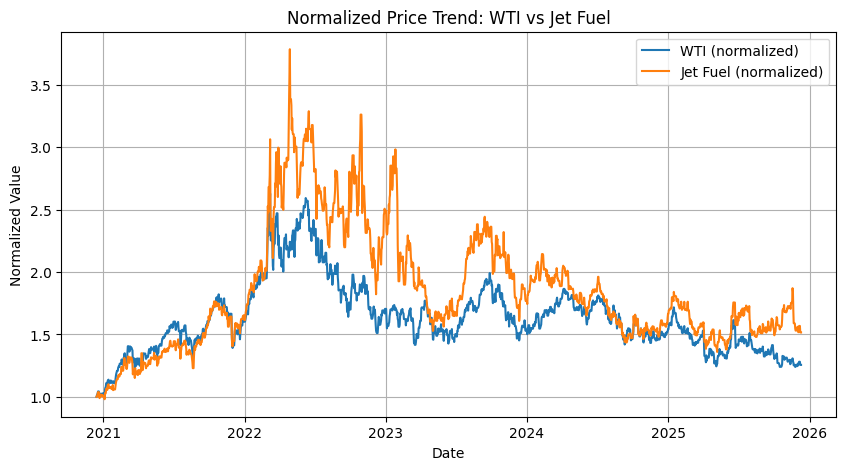

```python
# Section 4.1 — Normalized Price Trend: WTI vs Jet Fuel

import matplotlib.pyplot as plt

# Normalize both series to start at 1
normalized = prices[["WTI", "JetFuel"]] / prices[["WTI", "JetFuel"]].iloc[0]

plt.figure(figsize=(10,5))
plt.plot(normalized.index, normalized["WTI"], label="WTI (normalized)")
plt.plot(normalized.index, normalized["JetFuel"], label="Jet Fuel (normalized)")
plt.title("Normalized Price Trend: WTI vs Jet Fuel")
plt.xlabel("Date")
plt.ylabel("Normalized Value")
plt.legend()
plt.grid(True)
plt.show()
```

The normalized price trend shows how WTI crude oil and jet fuel prices evolved relative to their starting values over the sample period. Both series generally move together, reflecting the strong cost link between crude oil and refined jet fuel. However, jet fuel displays noticeably larger swings, especially during 2022. It indicates higher sensitivity to refinery capacity, transportation constraints, and demand. After mid-2022, both commodities decline, but jet fuel continues to show sharper fluctuations, highlighting its greater volatility. Overall, the graph illustrates that while jet fuel follows the direction of WTI, it reacts more intensely to market changes, making it more volatile than crude oil.

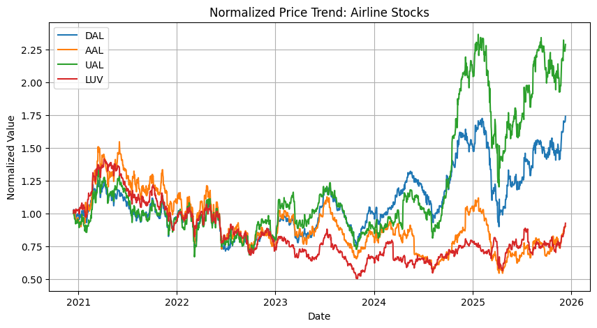

```python
# Section 4.2 — Normalized Airline Stock Prices

import matplotlib.pyplot as plt

# Normalize airline stock prices
normalized_stocks = prices[tickers] / prices[tickers].iloc[0]

plt.figure(figsize=(10,5))
for t in tickers:
    plt.plot(normalized_stocks.index, normalized_stocks[t], label=t)

plt.title("Normalized Price Trend: Airline Stocks")
plt.xlabel("Date")
plt.ylabel("Normalized Value")
plt.legend()
plt.grid(True)
plt.show()
```

## Section 4.2. Daily Returns Distributions

Here we visualize the distribution of daily log returns for crude oil, jet fuel, and each airline stock. The histograms show how frequently small or large return movements occur and give a sense of the volatility of each series. This helps compare how stable or unstable each market is and reveals whether any series experiences more extreme price changes.

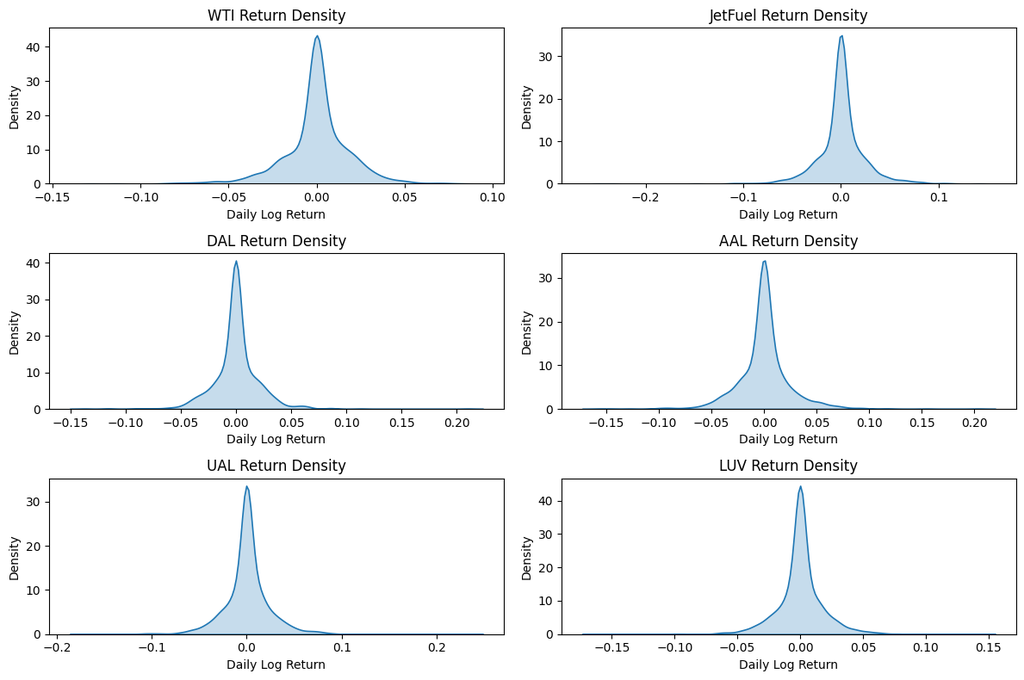

```python
# Cleaner return distributions using density plots

import matplotlib.pyplot as plt
import seaborn as sns

plt.figure(figsize=(12,8))

for i, col in enumerate(returns.columns, 1):
    plt.subplot(3, 2, i)
    sns.kdeplot(returns[col], fill=True, linewidth=1.2)
    plt.title(f"{col} Return Density")
    plt.xlabel("Daily Log Return")
    plt.ylabel("Density")

plt.tight_layout()
plt.show()
```

These density plots show that daily returns for oil, jet fuel, and airline stocks are tightly centered around zero with occasional larger movements in both directions. The narrow peaks and long tails indicate that small price changes are common while large jumps occur less frequently, which is typical for financial return series.

## Section 4.3. Correlation Heatmap of Daily Returns

In this step, we calculate the correlation matrix of all daily return series and visualize it as a heatmap. This shows how strongly each variable tends to move with the others on average. The heatmap helps identify whether jet fuel returns are more closely linked to oil or to specific airline stocks and whether some airlines move similarly to each other.

For more info, check: https://www.geeksforgeeks.org/python/seaborn-heatmap-a-comprehensive-guide/

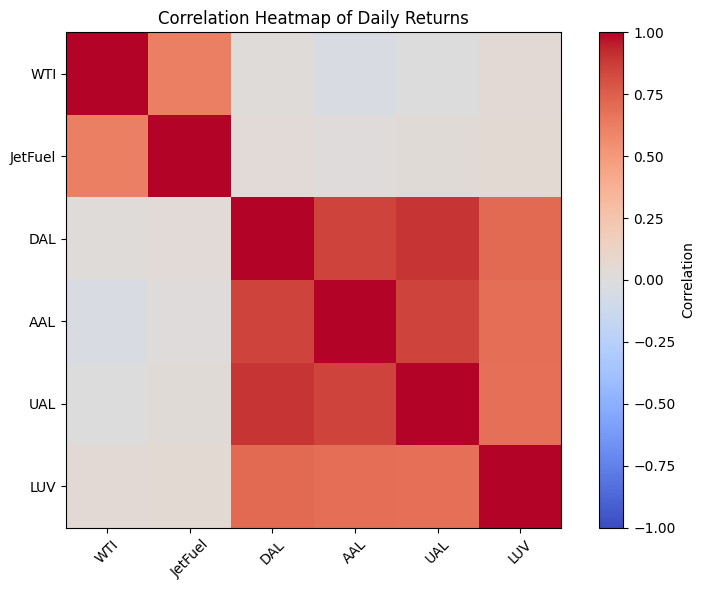

```
Correlation matrix:
              WTI   JetFuel       DAL       AAL       UAL       LUV
WTI      1.000000  0.617698  0.019684 -0.032542 -0.000403  0.040003
JetFuel  0.617698  1.000000  0.034792  0.014019  0.024912  0.047032
DAL      0.019684  0.034792  1.000000  0.845585  0.893416  0.710130
AAL     -0.032542  0.014019  0.845585  1.000000  0.849938  0.687860
UAL     -0.000403  0.024912  0.893416  0.849938  1.000000  0.683954
LUV      0.040003  0.047032  0.710130  0.687860  0.683954  1.000000
```

```python
# Section 4.4 — Correlation Heatmap

import matplotlib.pyplot as plt
import numpy as np

corr_matrix = returns.corr()

plt.figure(figsize=(8,6))
plt.imshow(corr_matrix, cmap="coolwarm", vmin=-1, vmax=1)
plt.colorbar(label="Correlation")
plt.xticks(range(len(corr_matrix.columns)), corr_matrix.columns, rotation=45)
plt.yticks(range(len(corr_matrix.columns)), corr_matrix.columns)
plt.title("Correlation Heatmap of Daily Returns")
plt.tight_layout()
plt.show()

print("Correlation matrix:")
print(corr_matrix)
```

This heatmap shows how strongly each pair of assets moves together based on their daily log returns. Jet fuel has a clear positive relationship with crude oil, which means changes in crude oil tend to appear in jet fuel prices. The airline stocks also move closely together, which reflects their shared exposure to industry conditions and similar demand factors. The relationships between oil or jet fuel and airline stocks are much weaker, which means daily fuel price movements do not directly translate into daily stock movements. This tells us that the link between fuel prices and airline performance is not immediate on a daily basis and may work through slower or more complex channels. Overall, the heatmap suggests that fuel markets are tightly connected with each other while airline stocks form a separate cluster with strong internal connections.

## Section 4.5. Rolling 30-Day Correlation: Jet Fuel vs Airline Stocks

Here we calculate the 30-day rolling correlations between jet fuel returns and each airline’s daily returns. This shows how sensitive each airline is to fuel price movements over time. The rolling view lets us see when the connection strengthens, weakens, or temporarily breaks, which helps identify which airlines react more or less to fuel cost changes.

For more info, check: https://www.geeksforgeeks.org/python/how-to-calculate-rolling-correlation-in-python/

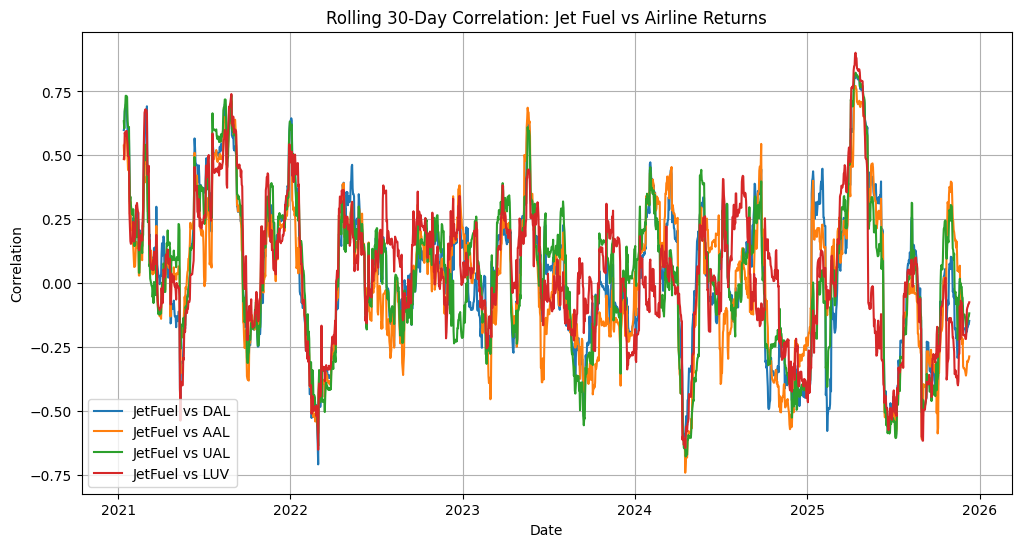

```python
# Section 4.5 — Rolling 30-Day Correlations: Jet Fuel vs Airlines

window = 30
plt.figure(figsize=(12,6))

for t in tickers:
    rolling_corr = returns["JetFuel"].rolling(window).corr(returns[t])
    plt.plot(rolling_corr.index, rolling_corr, label=f"JetFuel vs {t}")

plt.title("Rolling 30-Day Correlation: Jet Fuel vs Airline Returns")
plt.xlabel("Date")
plt.ylabel("Correlation")
plt.grid(True)
plt.legend()
plt.show()
```

This rolling correlation chart shows how the relationship between jet fuel returns and each airline stock changes over time. The correlations move up and down frequently, which means the link between fuel prices and airline returns is not stable but shifts with market conditions. At some points the correlations rise above zero, showing periods when airline stocks move in the same direction as jet fuel. At other times the correlations fall toward zero or become negative, showing weaker or even opposite movements. These fluctuations suggest that fuel costs do not have a constant daily effect on airline performance and that other factors such as demand, earnings news, and broad market conditions often dominate. Overall, the rolling correlations indicate that the influence of jet fuel on airline returns is variable and depends on the economic environment rather than following a fixed pattern.

## Section 4.6. Scatterplots: Jet Fuel vs Airline Returns

In this step, we create scatterplots comparing daily jet fuel returns with the daily returns of each airline. Each point represents one trading day. These charts help visualize whether increases in jet fuel prices tend to be associated with negative airline returns, or whether the relationship is weak and noisy. They also reveal whether any airline reacts more strongly to fuel price movements than others.

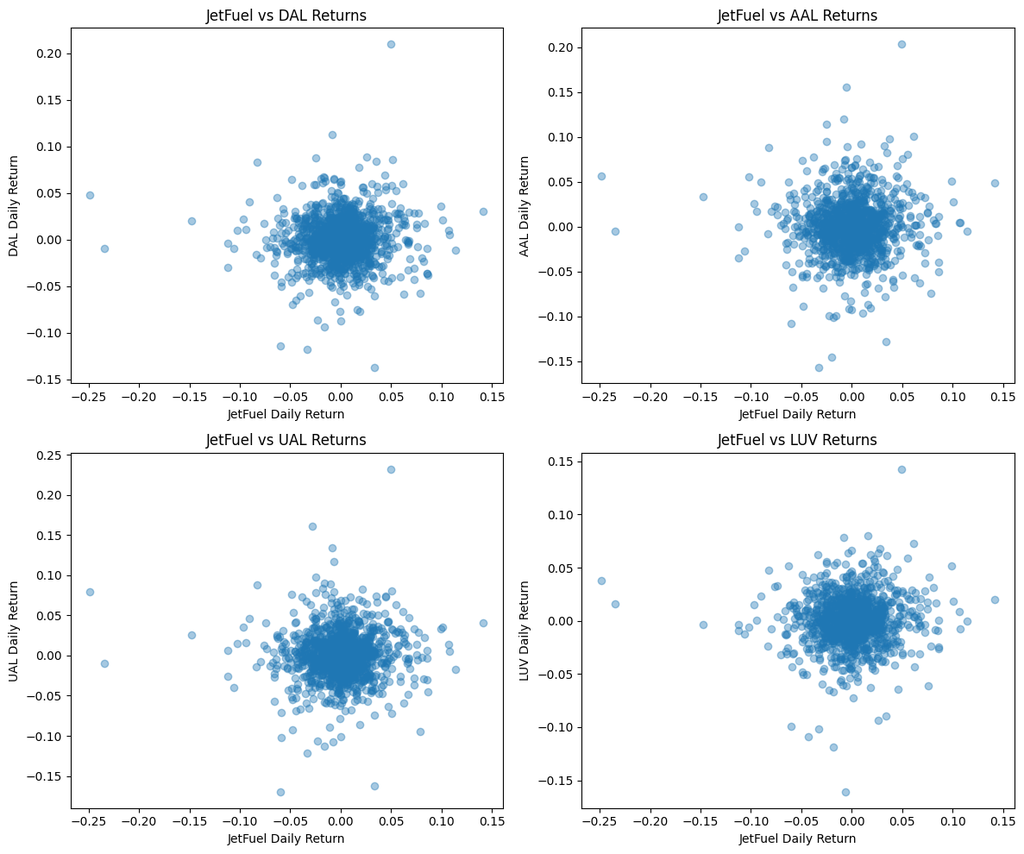

```python
# Section 4.6 — Scatterplots: Jet Fuel Returns vs Airline Returns

import matplotlib.pyplot as plt

plt.figure(figsize=(12,10))

for i, t in enumerate(tickers, 1):
    plt.subplot(2, 2, i)
    plt.scatter(returns["JetFuel"], returns[t], alpha=0.4)
    plt.title(f"JetFuel vs {t} Returns")
    plt.xlabel("JetFuel Daily Return")
    plt.ylabel(f"{t} Daily Return")

plt.tight_layout()
plt.show()
```

The scatterplots show almost no strong pattern between jet fuel returns and airline returns. Most points cluster tightly around zero on both axes, and the ranges are small: jet fuel daily returns mostly fall between -0.10 and 0.10, while airline returns typically fall between -0.08 and 0.08. The weak shape and wide spread indicate that the relationship is extremely noisy, with correlations near zero — consistent with the heatmap showing values around 0.02–0.05. This means daily fuel price changes do not reliably predict daily airline stock movements.

### Section 4.7. 30-Day Rolling Volatility for WTI, Jet Fuel, and Airline Stocks

In this step, we compute the 30-day rolling volatility (standard deviation of daily returns) for WTI crude oil, jet fuel, and the average of the four airline stocks. This allows us to examine how market risk evolves over time and whether volatility shocks in energy markets spill over into airline equities. Rolling volatility is one of the most standard diagnostics in time-series finance and helps identify periods of stress, instability, and market turbulence.

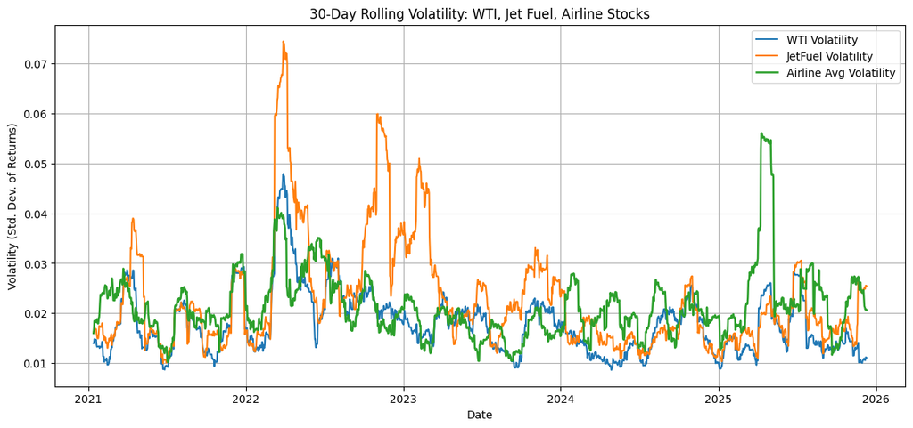

```python
# Section 4.7 — Rolling Volatility (30-Day)

plt.figure(figsize=(14, 6))

# Compute 30-day rolling standard deviation of returns
rolling_vol = returns.rolling(window=30).std()

# Plot WTI and JetFuel volatility
plt.plot(rolling_vol['WTI'], label='WTI Volatility', linewidth=1.5)
plt.plot(rolling_vol['JetFuel'], label='JetFuel Volatility', linewidth=1.5)

# Plot average airline volatility as a single smooth line
airline_vol_mean = rolling_vol[['DAL', 'AAL', 'UAL', 'LUV']].mean(axis=1)
plt.plot(airline_vol_mean, label='Airline Avg Volatility', linewidth=1.8)

plt.title('30-Day Rolling Volatility: WTI, Jet Fuel, Airline Stocks')
plt.xlabel('Date')
plt.ylabel('Volatility (Std. Dev. of Returns)')
plt.legend()
plt.grid(True)
plt.show()
```

This chart shows how the volatility of crude oil, jet fuel, and airline stocks changes over time using a rolling thirty day window. Volatility rises and falls throughout the sample period, which indicates that all three markets experience periods of calm and periods of stress. Jet fuel displays the highest and most frequent spikes, showing that fuel prices react more sharply to supply disruptions and refinery conditions. Airline stocks also show several large jumps in volatility, especially during market wide shocks, which reflects how sensitive airlines are to changes in demand and industry news. Crude oil moves more steadily and shows smaller swings overall, which suggests that it is the most stable of the three series. These patterns help us understand that volatility is not constant and that the risk faced by airlines and fuel markets varies significantly across time.

### Section 4.8. Lagged Cross-Correlation: Fuel vs Airline Stocks

In this step, we compute lagged cross-correlations between jet fuel returns and airline stock returns. The purpose is to test whether movements in fuel prices lead or lag airline market reactions. We calculate correlations at multiple lags (e.g., −10 to +10 days). A positive lag indicates that jet fuel moves first and airline stocks react later; a negative lag indicates the opposite. This analysis helps identify short-term predictive relationships useful for forecasting and risk management.

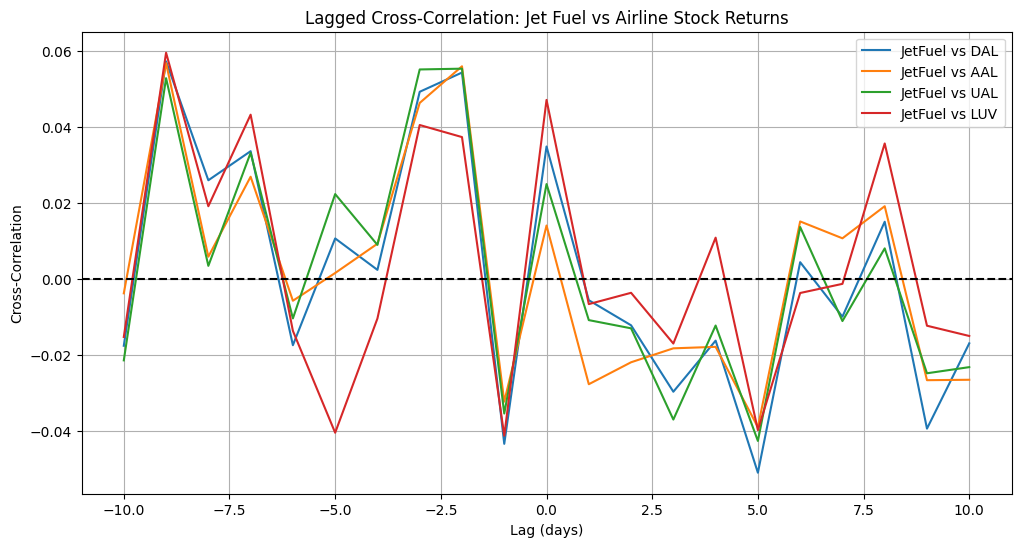

```python
# Section 4.8 — Lagged Cross-Correlation

import numpy as np

# Define lag range (e.g., -10 to +10 days)
lags = range(-10, 11)

def cross_corr(series1, series2, lag):
    """Computes correlation with the specified lag."""
    if lag > 0:
        return series1.shift(lag).corr(series2)
    elif lag < 0:
        return series1.corr(series2.shift(-lag))
    else:
        return series1.corr(series2)

results = {}

for ticker in ['DAL', 'AAL', 'UAL', 'LUV']:
    results[ticker] = [cross_corr(returns['JetFuel'], returns[ticker], lag) for lag in lags]

# Plot results
plt.figure(figsize=(12, 6))
for ticker in results:
    plt.plot(lags, results[ticker], label=f'JetFuel vs {ticker}')

plt.axhline(0, color='black', linestyle='--')
plt.xlabel('Lag (days)')
plt.ylabel('Cross-Correlation')
plt.title('Lagged Cross-Correlation: Jet Fuel vs Airline Stock Returns')
plt.legend()
plt.grid(True)
plt.show()
```

### 5.1. Regression Setup 1: Modeling How Oil and Jet Fuel Affect Airline Stock Returns

In this section, we estimate how changes in WTI crude oil prices and jet fuel prices affect airline stock returns. We use a simple linear regression model where daily airline stock returns are explained by daily returns of WTI and Jet Fuel. This helps us quantify whether fuel markets have a measurable impact on airline performance, and which fuel variable is more influential. We estimate separate models for each airline to compare sensitivity across carriers.

```python
import statsmodels.api as sm

# Prepare regression dataset
reg_data = returns[['WTI', 'JetFuel', 'DAL', 'AAL', 'UAL', 'LUV']].dropna()

# Function to run regression for each airline
def run_regression(y_col):
    X = reg_data[['WTI', 'JetFuel']]
    X = sm.add_constant(X)
    y = reg_data[y_col]
    model = sm.OLS(y, X).fit()
    return model

# Run models
model_DAL = run_regression('DAL')
model_AAL = run_regression('AAL')
model_UAL = run_regression('UAL')
model_LUV = run_regression('LUV')

# Print summaries
print("=== DAL Regression ===")
print(model_DAL.summary())

print("\n=== AAL Regression ===")
print(model_AAL.summary())

print("\n=== UAL Regression ===")
print(model_UAL.summary())

print("\n=== LUV Regression ===")
print(model_LUV.summary())
```

```
=== DAL Regression ===
                            OLS Regression Results
==============================================================================
Dep. Variable:                    DAL   R-squared:                       0.001
Model:                            OLS   Adj. R-squared:                  0.000
Method:                 Least Squares   F-statistic:                     1.107
Date:                Wed, 10 Dec 2025   Prob (F-statistic):              0.331
Time:                        19:52:49   Log-Likelihood:                 4468.6
No. Observations:                1822   AIC:                            -8931.
Df Residuals:                    1819   BIC:                            -8915.
Df Model:                           2
Covariance Type:            nonrobust
==============================================================================
                 coef    std err          t      P>|t|      [0.025      0.975]
------------------------------------------------------------------------------
const          0.0003      0.000      0.609      0.542      -0.001       0.001
WTI           -0.0032      0.033     -0.098      0.922      -0.068       0.062
JetFuel        0.0305      0.025      1.228      0.220      -0.018       0.079
==============================================================================
Omnibus:                      370.980   Durbin-Watson:                   2.147
Prob(Omnibus):                  0.000   Jarque-Bera (JB):             7250.368
Skew:                           0.407   Prob(JB):                         0.00
Kurtosis:                      12.739   Cond. No.                         77.1
==============================================================================

Notes:
[1] Standard Errors assume that the covariance matrix of the errors is correctly specified.

=== AAL Regression ===
                            OLS Regression Results
==============================================================================
Dep. Variable:                    AAL   R-squared:                       0.003
Model:                            OLS   Adj. R-squared:                  0.002
Method:                 Least Squares   F-statistic:                     2.683
Date:                Wed, 10 Dec 2025   Prob (F-statistic):             0.0686
Time:                        19:52:49   Log-Likelihood:                 4137.6
No. Observations:                1822   AIC:                            -8269.
Df Residuals:                    1819   BIC:                            -8253.
Df Model:                           2
Covariance Type:            nonrobust
```

[output cut: 56 more lines]

```
==============================================================================
                 coef    std err          t      P>|t|      [0.025      0.975]
------------------------------------------------------------------------------
const       -5.16e-05      0.000     -0.116      0.908      -0.001       0.001
WTI            0.0180      0.030      0.595      0.552      -0.041       0.077
JetFuel        0.0275      0.023      1.212      0.226      -0.017       0.072
==============================================================================
Omnibus:                      353.949   Durbin-Watson:                   2.101
Prob(Omnibus):                  0.000   Jarque-Bera (JB):             5195.931
Skew:                          -0.469   Prob(JB):                         0.00
Kurtosis:                      11.220   Cond. No.                         77.1
==============================================================================

Notes:
[1] Standard Errors assume that the covariance matrix of the errors is correctly specified.
```

## 5.2 Regression Setup 2: Modeling How Oil and Jet Fuel Affect Airline Stock Returns

Rolling window regression is used to examine how the relationship between fuel prices and airline stock returns changes over time. Instead of fitting one single regression to the entire dataset, the model is repeatedly estimated on a short moving window, such as sixty days. This approach recognizes that financial relationships are not constant and may shift due to changes in demand conditions, market events, or economic cycles. Rolling regression allows us to see whether the sensitivity of airline returns to WTI and jet fuel becomes stronger, weaker, or changes sign during specific periods. This model does not focus on predicting future values but instead evaluates the stability and time variation of the relationship, which directly supports the research goal of understanding how fuel markets influence airline performance.

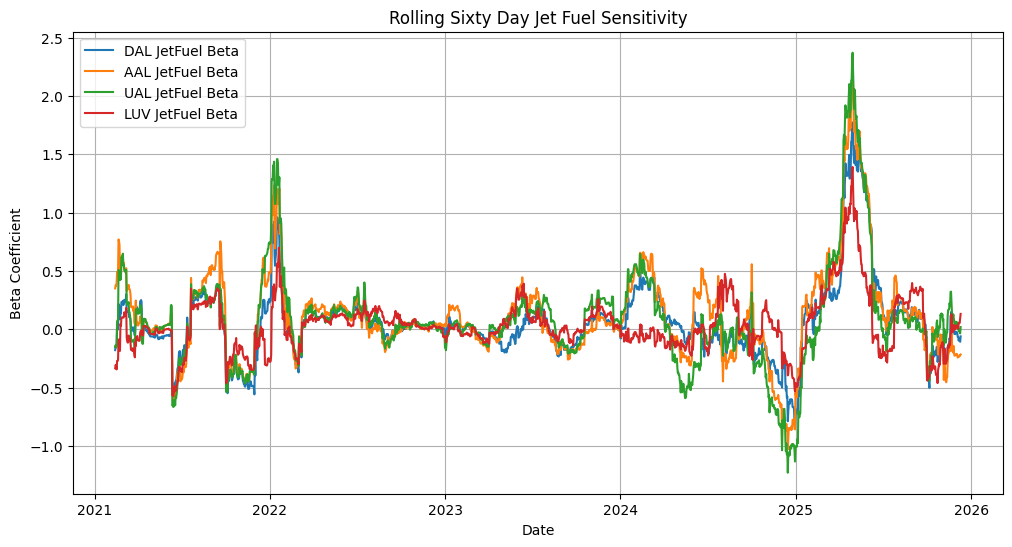

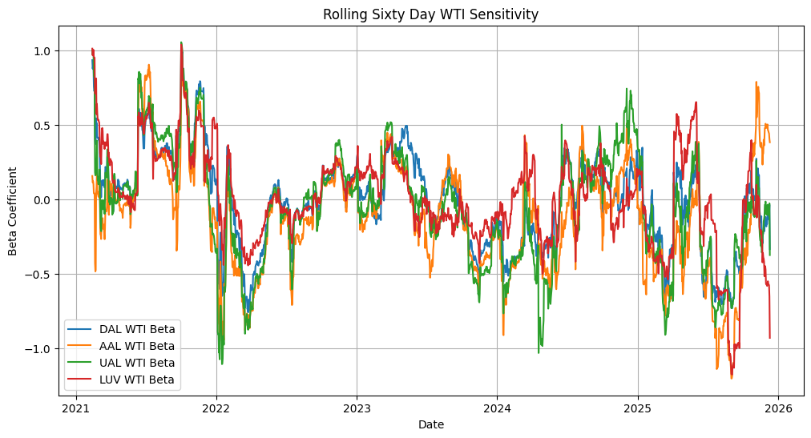

```python
# Rolling Window Regression

import pandas as pd
import statsmodels.api as sm
import matplotlib.pyplot as plt

window = 60  # 60 day window

rolling_betas = {ticker: {'WTI': [], 'JetFuel': [], 'Date': []} for ticker in ['DAL', 'AAL', 'UAL', 'LUV']}

for ticker in ['DAL', 'AAL', 'UAL', 'LUV']:
    for i in range(window, len(reg_data)):
        y = reg_data[ticker].iloc[i-window:i]
        X = reg_data[['WTI', 'JetFuel']].iloc[i-window:i]
        X = sm.add_constant(X)

        model = sm.OLS(y, X).fit()
        rolling_betas[ticker]['WTI'].append(model.params['WTI'])
        rolling_betas[ticker]['JetFuel'].append(model.params['JetFuel'])
        rolling_betas[ticker]['Date'].append(reg_data.index[i])

# Plot rolling betas for Jet Fuel
plt.figure(figsize=(12,6))
for ticker in ['DAL', 'AAL', 'UAL', 'LUV']:
    plt.plot(rolling_betas[ticker]['Date'], rolling_betas[ticker]['JetFuel'], label=f"{ticker} JetFuel Beta")
plt.title("Rolling Sixty Day Jet Fuel Sensitivity")
plt.xlabel("Date")
plt.ylabel("Beta Coefficient")
plt.legend()
plt.grid(True)
plt.show()

# Plot rolling betas for WTI
plt.figure(figsize=(12,6))
for ticker in ['DAL', 'AAL', 'UAL', 'LUV']:
    plt.plot(rolling_betas[ticker]['Date'], rolling_betas[ticker]['WTI'], label=f"{ticker} WTI Beta")
plt.title("Rolling Sixty Day WTI Sensitivity")
plt.xlabel("Date")
plt.ylabel("Beta Coefficient")
plt.legend()
plt.grid(True)
plt.show()
```

### 5.3. Event Study: Market Responses to Major Energy and Geopolitical Shocks

In this section, we conduct an event study to evaluate how major geopolitical and energy-related shocks affect short-horizon movements in crude oil prices, jet fuel prices, and U.S. airline stock returns. We use a symmetric ±15-day event window around each event date. This one-month window captures the immediate market reaction as well as the short-run adjustment period that typically follows large supply shocks or geopolitical disruptions. Such events often unfold over several trading weeks, making a wider window appropriate for this context.

We compute cumulative returns for all variables—including WTI crude oil, jet fuel, and the airline stocks DAL, AAL, UAL, and LUV—so that all series can be compared on a consistent scale. Daily returns are highly volatile and difficult to interpret during shock periods, whereas cumulative returns smooth out high-frequency noise and reveal the net directional impact over the full event window. This scaling also allows assets with different price levels to be shown together on a single figure.

By plotting cumulative returns for oil, jet fuel, and all airlines on each event, we can evaluate relative sensitivity to energy shocks. Oil and jet fuel typically react in the same direction, while airlines often respond inversely because higher fuel costs reduce profitability. The patterns in these windows help us understand the transmission of global supply disruptions into both energy markets and airline equity performance.

Event descriptions and expected short-run effects:

**Russia–Ukraine War (Feb 2022):** A major geopolitical shock increasing perceived supply risk. Expected to raise crude and jet fuel prices and place downward pressure on airline stocks.

**OPEC+ Production Cut (Oct 2022**): A planned reduction in output designed to support crude prices. Usually associated with higher fuel costs and weaker airline returns.

**OPEC+ Surprise Output Cut (Apr 2023)**: An unexpected supply cut that often produces sharper short-run adjustments in energy markets and adverse reactions in airline equities.

**Middle East Conflict Escalation (Oct 2023)**: A regional conflict raising uncertainty around production and transport routes. Typically increases volatility in energy markets and pressures airline performance.

```
Your dataset covers: 2020-12-15 00:00:00 to 2025-12-10 00:00:00
Using a one-month event window of ±15 days around each event.
```

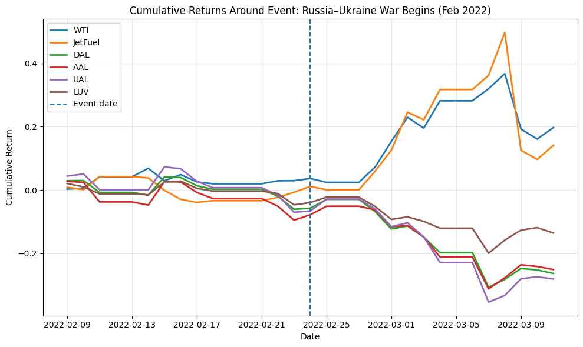

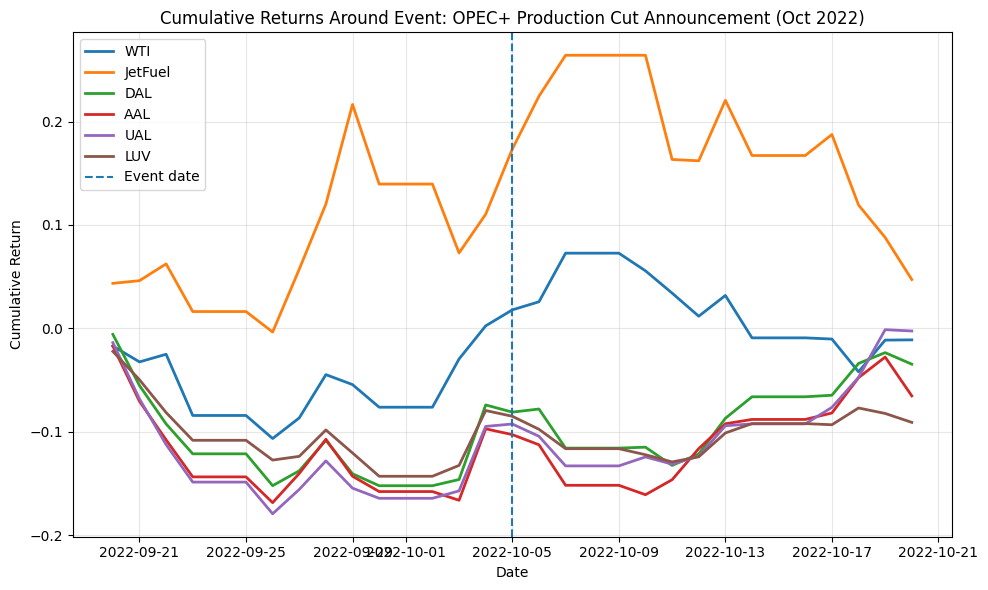

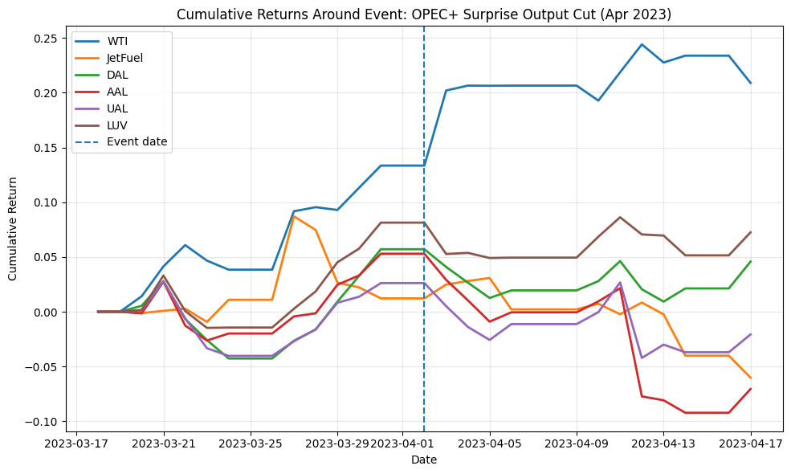

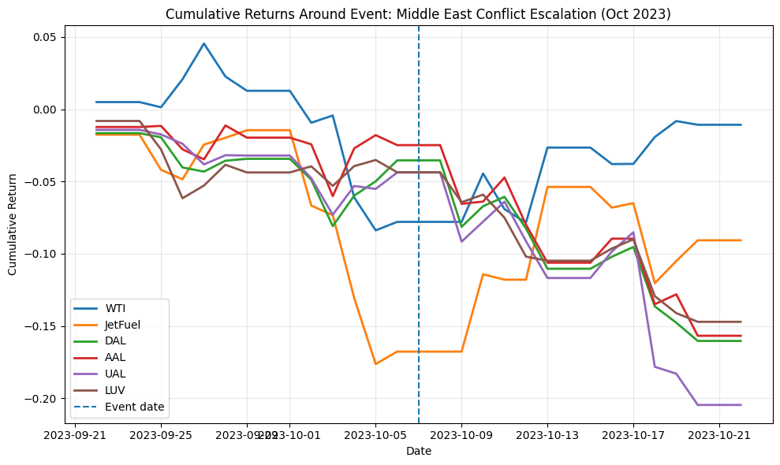

```python
# Section 6 — Event Study: Do Major Real-World Shocks Affect Airline Returns?

import matplotlib.pyplot as plt
import pandas as pd

# Define airline tickers used in the analysis
tickers = ["DAL", "AAL", "UAL", "LUV"]

# Events chosen to capture major oil-related shocks within the dataset range
events = {
    "Russia–Ukraine War Begins (Feb 2022)": "2022-02-24",
    "OPEC+ Production Cut Announcement (Oct 2022)": "2022-10-05",
    "OPEC+ Surprise Output Cut (Apr 2023)": "2023-04-02",
    "Middle East Conflict Escalation (Oct 2023)": "2023-10-07",
}

# One-month event window: 15 days before and 15 days after
window_days = 15

# Helper function to extract a symmetric event window
def get_event_window(df, event_date, window_days=15):
    event_date = pd.to_datetime(event_date)
    start = event_date - pd.Timedelta(days=window_days)
    end = event_date + pd.Timedelta(days=window_days)
    return df.loc[start:end]

# Columns to plot together (all daily log returns)
cols_to_plot = ["WTI", "JetFuel"] + tickers  # assumes these columns exist in returns

# Get available date range in your returns DataFrame
min_date = returns.index.min()
max_date = returns.index.max()

print("Your dataset covers:", min_date, "to", max_date)
print(f"Using a one-month event window of ±{window_days} days around each event.\n")

# Iterate through events and ONLY plot those with data
for event_name, event_date in events.items():

    event_date = pd.to_datetime(event_date)

    # Check if event is within your dataset range
    if event_date < min_date or event_date > max_date:
        print(f"Skipping '{event_name}' — event is outside dataset range.")
        continue

    # Extract window for all selected series (oil, jet fuel, and airlines)
    window_df = get_event_window(returns[cols_to_plot], event_date, window_days=window_days)

    # Skip if window is empty
    if window_df.empty:
        print(f"Skipping '{event_name}' — no data available for this window.")
        continue

    # Compute cumulative returns over the event window
    cum_df = (1 + window_df).cumprod() - 1

    # Plot cumulative returns for all series
    plt.figure(figsize=(10, 6))
    for col in cols_to_plot:
        plt.plot(cum_df.index, cum_df[col],
                 linewidth=2, label=col)

    # Mark event date
    plt.axvline(event_date, linestyle="--", label="Event date")

    plt.title(f"Cumulative Returns Around Event: {event_name}")
    plt.xlabel("Date")
    plt.ylabel("Cumulative Return")
    plt.grid(alpha=0.3)
    plt.legend()
    plt.tight_layout()
    plt.show()
```